### vector data - shapefiles

#### reading vector data into R

Using package **rgdal** we can use the gdal drivers to read ESRI shapefiles. As shapefiles have layers, we need to know which layer to load

```r
library(rgdal)
```

```r
#library(mapview)
```

first we set our working directory

```r
setwd('/home/ede/tappelhans/uni/marburg/lehre/2016/ss/PS_global_change')
```

then we can start working

```r
shp_file <- "data/gadm_deu/gadm_deu.shp"

lyr <- ogrListLayers(dsn = shp_file)
lyr
```

```
## [1] "gadm_deu"
## attr(,"driver")
## [1] "ESRI Shapefile"
## attr(,"nlayers")
## [1] 1
```

```r
gadm_deu <- readOGR(dsn = shp_file,
                    layer = lyr)
```

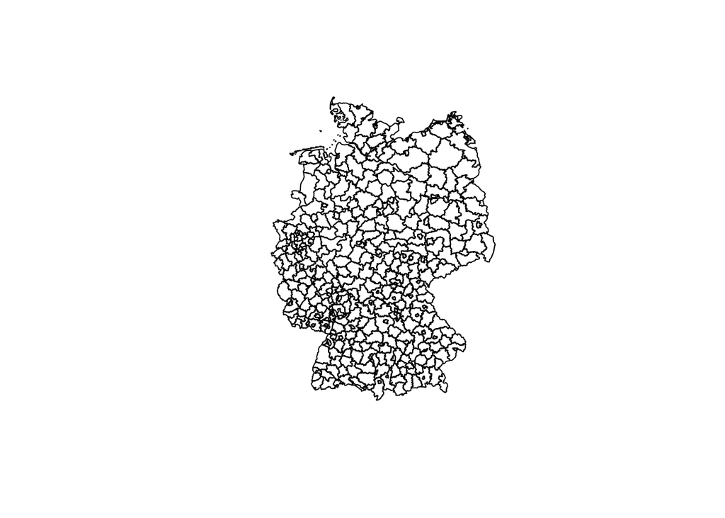

```r
plot(gadm_deu)
```

```r
#mapview(gadm_deu, color = "blue")
```

#### writing vector data to disk

the same drivers also handle writing of shapefiles

```r
writeOGR(obj = gadm_deu,
         dsn = "data/gadm_deu/my_shape.shp",
         layer = "my_shape",
         driver = "ESRI Shapefile",
         overwrite_layer = TRUE)
```

the `driver` argument can be used to write many different file formats

```r
ogrDrivers()
```

```
##              name write
## 1      AeronavFAA FALSE
## 2          ARCGEN FALSE
## 3          AVCBin FALSE
## 4          AVCE00 FALSE
## 5             BNA  TRUE
## 6         CartoDB FALSE
## 7         CouchDB  TRUE
## 8             CSV  TRUE
## 9             DGN  TRUE
## 10           DODS FALSE
## 11            DXF  TRUE
## 12         EDIGEO FALSE
## 13  ElasticSearch  TRUE
## 14 ESRI Shapefile  TRUE
```

[output cut: 54 more lines]

### raster data - geotifs

#### reading single raster data into R

With package **raster** it is easy to read valid raster formats such as GeoTiff. We simply need to pass the path to the file to the `raster()` function

```r
library(raster)

tmean01 <- raster("data/tmean_deu/tmean_deu_m01.tif")
tmean01
```

```
## class       : RasterLayer
## dimensions  : 187, 220, 41140  (nrow, ncol, ncell)
## resolution  : 0.04166667, 0.04166667  (x, y)
## extent      : 5.875, 15.04167, 47.25, 55.04167  (xmin, xmax, ymin, ymax)
## coord. ref. : +proj=longlat +ellps=WGS84 +towgs84=0,0,0,0,0,0,0 +no_defs
## data source : /home/ede/tappelhans/uni/marburg/lehre/2016/ss/PS_global_change/data/tmean_deu/tmean_deu_m01.tif
## names       : tmean_deu_m01
## values      : -92, 25  (min, max)
```

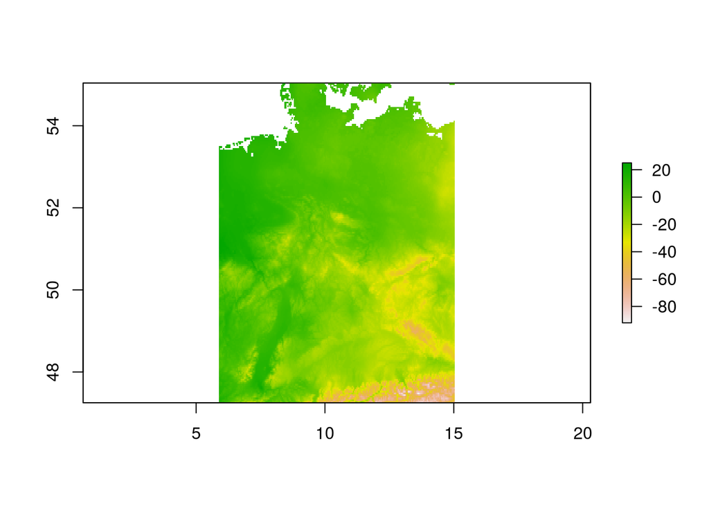

```r
plot(tmean01)
```

```r
#mapview(tmean01)
```

#### writing single raster data to disk

For writing raster data we use function `writeRaster()`

```r
writeRaster(tmean01,
            filename = "data/tmean_deu/my_raster_layer.tif",
            overwrite = TRUE)
```

for raster data we also have multiple file type options

```r
writeFormats()
```

```
##       name        long_name
##  [1,] "raster"    "R-raster"
##  [2,] "SAGA"      "SAGA GIS"
##  [3,] "IDRISI"    "IDRISI"
##  [4,] "IDRISIold" "IDRISI (img/doc)"
##  [5,] "BIL"       "Band by Line"
##  [6,] "BSQ"       "Band Sequential"
##  [7,] "BIP"       "Band by Pixel"
##  [8,] "ascii"     "Arc ASCII"
##  [9,] "CDF"       "NetCDF"
## [10,] "big"       "big.matrix"
## [11,] "ADRG"      "ARC Digitized Raster Graphics"
## [12,] "BMP"       "MS Windows Device Independent Bitmap"
## [13,] "BT"        "VTP .bt (Binary Terrain) 1.3 Format"
## [14,] "CTable2"   "CTable2 Datum Grid Shift"
```

[output cut: 28 more lines]

#### reading multiple raster data into R

If we want to read more than one raster file at a time, we can use R to `list.files()` in a folder containing a certain string and then pass this to `stack()`

```r
fls <- list.files(path = "data/tmean_deu",
                  pattern = glob2rx("tmean_deu_*.tif"),
                  full.names = TRUE)

fls
```

```
##  [1] "data/tmean_deu/tmean_deu_m01.tif" "data/tmean_deu/tmean_deu_m02.tif"
##  [3] "data/tmean_deu/tmean_deu_m03.tif" "data/tmean_deu/tmean_deu_m04.tif"
##  [5] "data/tmean_deu/tmean_deu_m05.tif" "data/tmean_deu/tmean_deu_m06.tif"
##  [7] "data/tmean_deu/tmean_deu_m07.tif" "data/tmean_deu/tmean_deu_m08.tif"
##  [9] "data/tmean_deu/tmean_deu_m09.tif" "data/tmean_deu/tmean_deu_m10.tif"
## [11] "data/tmean_deu/tmean_deu_m11.tif" "data/tmean_deu/tmean_deu_m12.tif"
```

```r
tmean_deu <- stack(x = fls)
tmean_deu
```

```
## class       : RasterStack
## dimensions  : 187, 220, 41140, 12  (nrow, ncol, ncell, nlayers)
## resolution  : 0.04166667, 0.04166667  (x, y)
## extent      : 5.875, 15.04167, 47.25, 55.04167  (xmin, xmax, ymin, ymax)
## coord. ref. : +proj=longlat +ellps=WGS84 +towgs84=0,0,0,0,0,0,0 +no_defs
## names       : tmean_deu_m01, tmean_deu_m02, tmean_deu_m03, tmean_deu_m04, tmean_deu_m05, tmean_deu_m06, tmean_deu_m07, tmean_deu_m08, tmean_deu_m09, tmean_deu_m10, tmean_deu_m11, tmean_deu_m12
## min values  :           -92,           -90,           -65,           -32,            14,            47,            67,            65,            39,             1,           -47,           -79
## max values  :            25,            30,            69,           104,           144,           177,           198,           192,           161,           111,            66,            39
```

#### writing multiple raster data to disk

this is also done using `writeRaster()`

```r
writeRaster(x = tmean_deu,
            filename = "data/tmean_deu/my_raster.tif",
            bylayer = TRUE,
            suffix = "names",
            overwrite = TRUE)
```